# 6. Worksheet: Among Site (Beta) Diversity – Part 1

## 3) QUANTIFYING BETA-DIVERSITY

In the R code chunk below, do the following:

1. write a function (`beta.w()`) to calculate Whittaker’s $\beta$-diversity (i.e., $\beta_{w}$) that accepts a site-by-species matrix with optional arguments to specify pairwise turnover between two sites, and
2. use this function to analyze various aspects of $\beta$-diversity in the Doubs River.

```r
beta = function(site.by_species = ""){
  SbyS.pa = decostand(site.by_species, method="pa") # convert to presence-absence matrix
  S = ncol(SbyS.pa[, which(colSums(SbyS.pa) > 0)]) # number of species in the region
  a.bar = mean(specnumber(SbyS.pa)) # average species richness
  b.w = round(S/a.bar, 3)
  return (b.w)
}
```

*Question 3*: Using your `beta.w()` function above, answer the following questions: > *Answer 3a: Describe how local richness ($\alpha$) and turnover ($\beta$) contribute to regional ($\gamma$) fish diversity in the Doubs.*:

```r
# Compute species richness for each site
alpha_richness = specnumber(doubs$fish)

# Compute beta diversity for each pair of sites
beta_diversity = beta(doubs$fish)

# Compute Gamma Diversity (Total number of unique species across all sites)
gamma_diversity = specnumber(colSums(doubs$fish > 0))

# Print out answers
print("Alpha Richness:")
```

```
## [1] "Alpha Richness:"
```

```r
print(alpha_richness)
```

```
##  1  2  3  4  5  6  7  8  9 10 11 12 13 14 15 16 17 18 19 20 21 22 23 24 25 26
##  1  3  4  8 11 10  5  0  5  6  6  6  6 10 11 17 22 23 23 22 23 22  3  8  8 21
## 27 28 29 30
## 22 22 26 21
```

```r
print(paste("Beta Diversity: ", beta_diversity))
```

```
## [1] "Beta Diversity:  2.16"
```

```r
print(paste("Gamma Diversity: ", gamma_diversity))
```

```
## [1] "Gamma Diversity:  27"
```

> *Answer 3b. Is the fish assemblage at site 1 more similar to the one at site 2 or site 10?*

```r
# Compute beta diversity between site 1 and site 2

beta_diversity_1_2 = beta(doubs$fish[c(1, 2), ])
beta_diversity_1_10 = beta(doubs$fish[c(1, 10), ])
beta_diversity_2_10 = beta(doubs$fish[c(2, 10), ])
# Check which pair of sites has the lowest beta diversity
print("The pair of sites with the lowest beta diversity is:")
```

```
## [1] "The pair of sites with the lowest beta diversity is:"
```

```r
print(paste("Site 1 and Site 2: ", beta_diversity_1_2))
```

```
## [1] "Site 1 and Site 2:  1.5"
```

```r
print(paste("Site 1 and Site 10: ", beta_diversity_1_10))
```

```
## [1] "Site 1 and Site 10:  1.714"
```

> The fish assemblage at site 1 is more similar to the one at site 2 than site 10.

> *Answer 3c: Using your understanding of the equation $\beta_{w} = \gamma/\alpha$, how would your interpretation of $\beta$ change if we instead defined beta additively (i.e., $\beta = \gamma - \alpha$)?* If we define beta additively, the beta diversity would be the absolute difference between total species richness and average local richness. In this case, we measure how many species are exclusive to different sites, rather than how many times local diversity fits into the total diversity.

### The Resemblance Matrix

In order to quantify $\beta$-diversity for more than two samples, we need to introduce a new primary ecological data structure: the **Resemblance Matrix**.

*Question 4*: How do incidence- and abundance-based metrics differ in their treatment of rare species?

> *Answer 4*:  
> Incidence-based metrics treat all species as equal, regardless of their count. They focus on the presence or absence of species in different sites. Abundance-based metrics, on the other hand, actually consider the abundance of species in addition to their presence or absence. They take into account the relative abundance of species in different sites.

In the R code chunk below, do the following:

> *1. make a new object, `fish`, containing the fish abundance data for the Doubs River,* *2. remove any sites where no fish were observed (i.e., rows with sum of zero),* *3. construct a resemblance matrix based on Sørensen’s Similarity (“fish.ds”), and* *4. construct a resemblance matrix based on Bray-Curtis Distance (“fish.db”).*

```r
# Q4.a
fish = doubs$fish
# Q4.b
fish = fish[rowSums(fish) > 0, ]
# Q4.c
fish.ds = vegdist(fish, method = "bray", binary=TRUE)
fish.db = vegdist(fish, method = "bray")
print("Resemblance Matrices using Sorensen's Similarity")
```

```
## [1] "Resemblance Matrices using Sorensen's Similarity"
```

```r
fish.ds
```

```
##             1          2          3          4          5          6          7
## 2  0.50000000
## 3  0.60000000 0.14285714
## 4  0.77777778 0.45454545 0.33333333
## 5  0.83333333 0.57142857 0.46666667 0.15789474
## 6  0.81818182 0.53846154 0.42857143 0.11111111 0.04761905
## 7  0.66666667 0.25000000 0.33333333 0.38461538 0.37500000 0.33333333
## 9  1.00000000 0.50000000 0.55555556 0.38461538 0.37500000 0.33333333 0.40000000
## 10 0.71428571 0.33333333 0.40000000 0.28571429 0.29411765 0.25000000 0.09090909
## 11 0.71428571 0.33333333 0.40000000 0.42857143 0.52941176 0.50000000 0.27272727
## 12 0.71428571 0.33333333 0.40000000 0.42857143 0.52941176 0.50000000 0.27272727
## 13 0.71428571 0.33333333 0.40000000 0.57142857 0.64705882 0.62500000 0.45454545
## 14 0.81818182 0.53846154 0.42857143 0.33333333 0.42857143 0.40000000 0.46666667
## 15 0.83333333 0.57142857 0.60000000 0.36842105 0.36363636 0.33333333 0.37500000
## 16 0.88888889 0.70000000 0.61904762 0.36000000 0.28571429 0.25925926 0.54545455
## 17 0.91304348 0.76000000 0.69230769 0.46666667 0.39393939 0.37500000 0.62962963
## 18 0.91666667 0.76923077 0.70370370 0.48387097 0.41176471 0.39393939 0.64285714
## 19 1.00000000 0.84615385 0.77777778 0.54838710 0.41176471 0.45454545 0.71428571
## 20 1.00000000 0.84000000 0.76923077 0.53333333 0.39393939 0.43750000 0.70370370
## 21 1.00000000 0.84615385 0.77777778 0.54838710 0.41176471 0.45454545 0.71428571
## 22 1.00000000 0.92000000 0.84615385 0.60000000 0.45454545 0.50000000 0.77777778
## 23 1.00000000 1.00000000 1.00000000 0.81818182 0.71428571 0.69230769 0.75000000
## 24 1.00000000 1.00000000 1.00000000 0.75000000 0.68421053 0.66666667 0.84615385
## 25 1.00000000 1.00000000 0.83333333 0.62500000 0.36842105 0.44444444 0.69230769
## 26 1.00000000 0.91666667 0.84000000 0.58620690 0.43750000 0.48387097 0.76923077
## 27 1.00000000 0.92000000 0.84615385 0.60000000 0.45454545 0.50000000 0.77777778
## 28 1.00000000 0.92000000 0.84615385 0.60000000 0.45454545 0.50000000 0.77777778
## 29 0.92592593 0.79310345 0.73333333 0.52941176 0.40540541 0.44444444 0.67741935
## 30 1.00000000 1.00000000 0.92000000 0.65517241 0.50000000 0.54838710 0.84615385
##             9         10         11         12         13         14         15
## 2
## 3
## 4
## 5
## 6
## 7
## 9
## 10 0.45454545
## 11 0.45454545 0.33333333
## 12 0.45454545 0.33333333 0.00000000
```

[output cut: 61 more lines]

```
## 16
## 17
## 18
## 19
## 20
## 21
## 22
## 23
## 24 0.45454545
## 25 0.45454545 0.37500000
## 26 0.75000000 0.44827586 0.44827586
## 27 0.76000000 0.46666667 0.46666667 0.02325581
## 28 0.76000000 0.46666667 0.46666667 0.02325581 0.00000000
## 29 0.79310345 0.52941176 0.52941176 0.10638298 0.08333333 0.08333333
## 30 0.75000000 0.44827586 0.44827586 0.04761905 0.02325581 0.02325581 0.10638298
```

```r
print("Resemblance Matrices using Bray-Curtis Distance")
```

```
## [1] "Resemblance Matrices using Bray-Curtis Distance"
```

```r
fish.db
```

```
##             1          2          3          4          5          6          7
## 2  0.60000000
## 3  0.68421053 0.14285714
## 4  0.75000000 0.33333333 0.18918919
## 5  0.89189189 0.69565217 0.68000000 0.49090909
## 6  0.75000000 0.39393939 0.29729730 0.19047619 0.41818182
## 7  0.68421053 0.14285714 0.12500000 0.24324324 0.64000000 0.24324324
## 9  1.00000000 0.69230769 0.73333333 0.65714286 0.58333333 0.54285714 0.66666667
## 10 0.88235294 0.38461538 0.40000000 0.37142857 0.54166667 0.25714286 0.26666667
## 11 0.57142857 0.30434783 0.40740741 0.43750000 0.68888889 0.43750000 0.33333333
## 12 0.71428571 0.20000000 0.23529412 0.33333333 0.69230769 0.38461538 0.17647059
## 13 0.72727273 0.29032258 0.31428571 0.45000000 0.73584906 0.55000000 0.37142857
## 14 0.80645161 0.40000000 0.31818182 0.34693878 0.67741935 0.42857143 0.36363636
## 15 0.83333333 0.51111111 0.46938776 0.40740741 0.55223881 0.37037037 0.38775510
## 16 0.86046512 0.65384615 0.57142857 0.47540984 0.45945946 0.37704918 0.53571429
## 17 0.91489362 0.67857143 0.63333333 0.50769231 0.51282051 0.44615385 0.60000000
## 18 0.95555556 0.74074074 0.72413793 0.58730159 0.50000000 0.52380952 0.68965517
## 19 1.00000000 0.79310345 0.70967742 0.61194030 0.50000000 0.52238806 0.67741935
## 20 1.00000000 0.91176471 0.88888889 0.74025974 0.48888889 0.68831169 0.86111111
## 21 1.00000000 0.94594595 0.92307692 0.78313253 0.50000000 0.73493976 0.89743590
## 22 1.00000000 0.97619048 0.95454545 0.82795699 0.52830189 0.78494624 0.93181818
## 23 1.00000000 1.00000000 1.00000000 0.92000000 0.89473684 0.84000000 0.90000000
## 24 1.00000000 1.00000000 1.00000000 0.88888889 0.79591837 0.77777778 0.93548387
## 25 1.00000000 1.00000000 0.92592593 0.81250000 0.68888889 0.68750000 0.85185185
## 26 1.00000000 0.96363636 0.93220339 0.78125000 0.55844156 0.68750000 0.89830508
## 27 1.00000000 0.97333333 0.94936709 0.83333333 0.56701031 0.76190476 0.92405063
## 28 1.00000000 0.97560976 0.95348837 0.82417582 0.57692308 0.78021978 0.93023256
## 29 0.97777778 0.93939394 0.92233010 0.81481481 0.53719008 0.77777778 0.90291262
## 30 1.00000000 1.00000000 0.98095238 0.87272727 0.59349593 0.83636364 0.96190476
##             9         10         11         12         13         14         15
## 2
## 3
## 4
## 5
## 6
## 7
## 9
## 10 0.57142857
## 11 0.76000000 0.44000000
## 12 0.68750000 0.37500000 0.24137931
```

[output cut: 61 more lines]

```
## 16
## 17
## 18
## 19
## 20
## 21
## 22
## 23
## 24 0.57894737
## 25 0.46666667 0.46153846
## 26 0.82978723 0.48275862 0.59259259
## 27 0.88059701 0.61538462 0.70270270 0.18867925
## 28 0.89189189 0.64705882 0.72839506 0.23893805 0.09774436
## 29 0.91208791 0.70588235 0.77551020 0.33846154 0.18666667 0.14649682
## 30 0.91397849 0.71153846 0.78000000 0.36363636 0.19736842 0.15723270 0.14772727
```

*Question 5*: Using the distance matrices from above, answer the following questions:

1. Does the resemblance matrix (`fish.db`) represent similarity or dissimilarity? What information in the resemblance matrix led you to arrive at your answer?
2. Compare the resemblance matrices (`fish.db` or `fish.ds`) you just created. How does the choice of the Sørensen or Bray-Curtis distance influence your interpretation of site (dis)similarity?

> *Answer 5a*:  
> The resemblance matrix `fish.db` represents dissimilarity. The values in the matrix are between 0 and 1, where 0 indicates that two sites are similar and 1 indicates that two sites are completely different. If we look at the formula of Bray-Curtis, we can see that the formula is a sum of the absolute differences between the species abundances of two sites. If two sites are similar in terms of species composition (not only presence of that species but also similar in the count), the difference would be 0, or at least close to 0, the Bray-Curtis distance will be low. If two sites are different, the Bray-Curtis distance will be high.

## 4) VISUALIZING BETA-DIVERSITY

### A. Heatmaps

In the R code chunk below, do the following:

1. define a color palette,
2. define the order of sites in the Doubs River, and
3. use the `levelplot()` function to create a heatmap of fish abundances in the Doubs River.

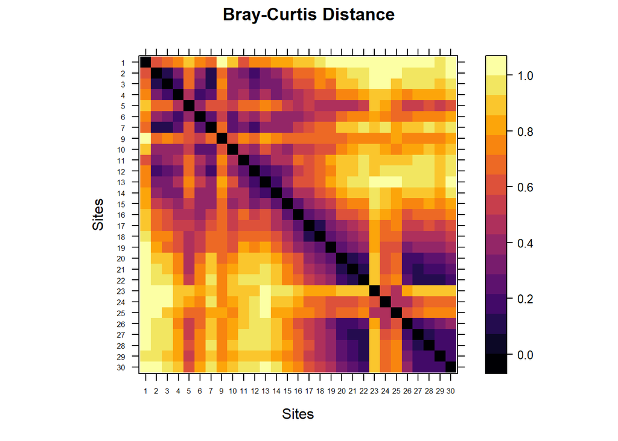

```r
# Define the order of the sites
order = rev(attr(fish.db, "Labels"))

# Heatmap
levelplot(as.matrix(fish.db)[, order],
  col.regions = inferno,
  aspect="iso",
  xlab = "Sites", ylab = "Sites",
  scales = list(cex=0.5),
  main = "Bray-Curtis Distance")
```

### B. Cluster Analysis

In the R code chunk below, do the following:

1. perform a cluster analysis using Ward’s Clustering, and
2. plot your cluster analysis (use either `hclust` or `heatmap.2`).

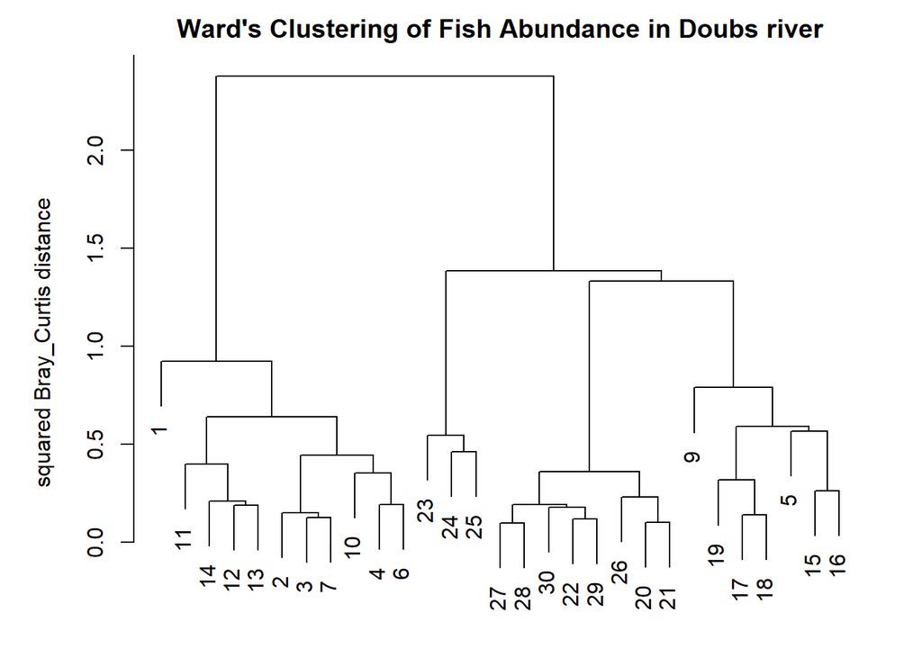

```r
# Perform cluster analysis
fish.ward = hclust(fish.db, method = "ward.D2")

# Plot cluster
par(mar=c(1,5,2,2) + 0.1)
plot(fish.ward, main = "Ward's Clustering of Fish Abundance in Doubs river",
  ylab = "squared Bray_Curtis distance")
```

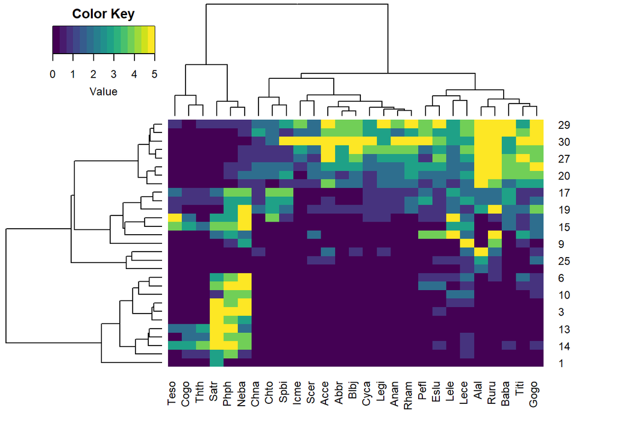

```r
gplots::heatmap.2(as.matrix(fish),
   distfun = function(x) vegdist(x, method = "bray"),
   hclustfun = function(x) hclust(x, method = "ward.D2"),
   col = viridis, trace = "none", density.info = "none")
```

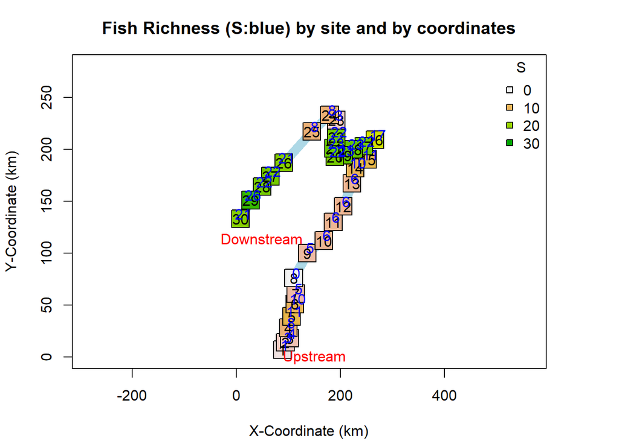

```r
# ------------------------------------------
# Replot the distribution of species richness by location
opar <- par(no.readonly = TRUE)
par(mfrow = c(1,  1), mar = c(4, 4, 3, 4) + 0.1, xpd = TRUE)

# Species Richness
plot.new()
plot(doubs$xy, asp = 2, type = 'l', lwd = 10, col = "light blue", xlim = c(0,280), ylim = c(0,280),
     main = "Fish Richness (S:blue) by site and by coordinates",
     xlab = "X-Coordinate (km)", ylab = "Y-Coordinate (km)")
points(doubs$xy, pch = 22, cex=3, bg = spa.S.color[spa.S + 1])
text(doubs$xy, as.character(rownames(doubs$xy)), cex = 1, col = "black")
text(doubs$xy + 5, as.character(spa.S), cex = 1, col = "blue")
text(150, 0, "Upstream", cex = 1, col = "red")
text(48, 114, "Downstream", cex = 1, col = "red")
legend("topright", pch = 22, pt.cex = 1, bty = 'n',
       title = "S", legend = seq(0, 30, 10),
       pt.bg = spa.S.color[seq(1, 31, 10)])
```

```r
par = opar
```

*Question 6*: Based on cluster analyses and the introductory plots that we generated after loading the data, develop an ecological hypothesis for fish diversity the `doubs` data set?

> *Answer 6*: In this clustering plot, we can see that nearer to the downstream, we have more species. This suggests that the fish community composition is different between the upstream and downstream of the Doubs River. This could be due maybe to differences in habitat quality, water quality, or other environmental factors. Based on this, we can hypothesize that the fish community composition in the Doubs River changes along the river gradient.

### Principal Coordinates Analysis (PCoA)

In the R code chunk below, do the following:

1. perform a Principal Coordinates Analysis to visualize beta-diversity
2. calculate the variation explained by the first three axes in your ordination
3. plot the PCoA ordination,
4. label the sites as points using the Doubs River site number, and

```r
# Calculate PCoA
fish.pcoa = cmdscale(fish.db, eig = TRUE, k = 3)
fish.pcoa
```

```
## $points
##           [,1]         [,2]         [,3]
## 1  -0.32043291  0.135094526  0.610444135
## 2  -0.50271272 -0.053204485  0.115084582
## 3  -0.47207593 -0.075509864  0.025191639
## 4  -0.31629787 -0.065793925 -0.054743001
## 5   0.06659050 -0.103685307 -0.061632012
## 6  -0.24164704  0.022330383 -0.117689415
## 7  -0.44197058  0.013721347 -0.019578989
## 9  -0.02864444  0.138633466 -0.189715336
## 10 -0.29305689  0.037682458 -0.202079336
## 11 -0.43875065  0.071482520  0.153768001
## 12 -0.47279103 -0.013160075 -0.006637071
## 13 -0.47550783 -0.100573921  0.079082050
## 14 -0.37472705 -0.070111200 -0.076607528
```

[output cut: 33 more lines]

```r
# Explained variance for first 3 axes
explained_variance = round(sum(fish.pcoa$eig[1:3]/sum(fish.pcoa$eig)) * 100, 2)
print("Explained variance of the 3 first axes:")
```

```
## [1] "Explained variance of the 3 first axes:"
```

```r
print(explained_variance)
```

```
## [1] 81.4
```

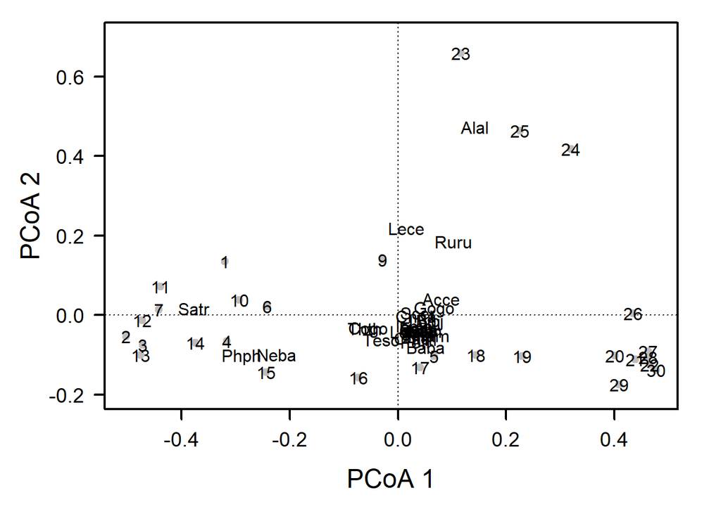

```r
# Define Plot Parameters
par(mar = c(5, 5, 1, 2) + 0.1)

# Initiate Plot
plot(fish.pcoa$points[ ,1], fish.pcoa$points[ ,2], ylim = c(-0.2, 0.7),
     xlab = "PCoA 1",
     ylab = "PCoA 2",
     pch = 16, cex = 2.0, type = "n", cex.lab = 1.5,
     cex.axis = 0.5, axes = FALSE)

# # Add Axes
axis(side = 1, labels = T, lwd.ticks = 2, cex.axis = 1.2, las = 1)
axis(side = 2, labels = T, lwd.ticks = 2, cex.axis = 1.2, las = 1)
abline(h = 0, v = 0, lty = 3)
box(lwd = 2)

# # Add Points & Labels
points(fish.pcoa$points[ ,1], fish.pcoa$points[ ,2],
       pch = 19, cex = 1, bg = "gray", col = "gray")
text(fish.pcoa$points[ ,1], fish.pcoa$points[ ,2],
     labels = row.names(fish.pcoa$points))


## Layer the fishes on the PCA plot
## ===================================================
# Relative abundance of each fsih
fishREL =fish
  for(i in 1:nrow(fish)){
    fishREL[i, ] = fish[i, ] / sum(fish[i, ])
    }

# Now, we use this information to calculate and add species scores
fish.pcoa = add.spec.scores(
  fish.pcoa,
  fishREL,
  method = "pcoa.scores")
# fish.pcoa
text(
  fish.pcoa$cproj[ ,1],
  fish.pcoa$cproj[ ,2],
  labels = row.names(fish.pcoa$cproj), col = "black")
```

```r
## ===================================================
# Quantitiatively determine the names of the influential species
spe.corr = add.spec.scores(fish.pcoa, fishREL, method = "cor.scores")$cproj
thres = 0.7
spe.corr # correlation of each species with the first two axes
```

```
##             Dim1        Dim2         Dim3
## Cogo -0.51482765 -0.18215901 -0.072493771
## Satr -0.65755705  0.01568556  0.673590464
## Phph -0.86746400 -0.16993159 -0.124630984
## Neba -0.76741139 -0.18556782 -0.369638303
## Thth -0.49177919 -0.14695731  0.008482829
## Teso -0.27862754 -0.30397390 -0.256885094
## Chna  0.67852376 -0.02836068 -0.036473404
## Chto  0.32879529 -0.38699081 -0.269705339
## Lele  0.12018082 -0.18717507 -0.448352524
## Lece  0.07290236  0.57840522 -0.396459547
## Baba  0.62696172 -0.53115226 -0.100687700
## Spbi  0.50746311 -0.39531008 -0.133488708
## Gogo  0.60796871  0.07542782 -0.296228387
## Eslu  0.36212467 -0.19005923 -0.085718516
## Pefl  0.36765239 -0.41186011 -0.108247401
## Rham  0.80887508 -0.41925666  0.141363010
## Legi  0.82017586 -0.17018026  0.124239408
## Scer  0.59181176  0.05518457  0.029158367
## Cyca  0.75951224 -0.44429261  0.173136584
## Titi  0.56832579 -0.36831053 -0.138049853
## Abbr  0.77047437 -0.34527139  0.292778034
## Icme  0.65659923 -0.30970901  0.351493014
## Acce  0.76351955  0.21557646  0.102881794
## Ruru  0.51227569  0.50525351 -0.241837628
## Blbj  0.81184827 -0.13246979  0.255811784
## Alal  0.44712826  0.81198434 -0.051671308
## Anan  0.79741215 -0.39189718  0.209449676
```

```r
# Identify influential species
imp.spp = spe.corr[abs(spe.corr[,1]) >= thres | abs(spe.corr[,2]) >= thres, ]
imp.spp
```

```
##            Dim1       Dim2        Dim3
## Phph -0.8674640 -0.1699316 -0.12463098
## Neba -0.7674114 -0.1855678 -0.36963830
## Rham  0.8088751 -0.4192567  0.14136301
## Legi  0.8201759 -0.1701803  0.12423941
## Cyca  0.7595122 -0.4442926  0.17313658
## Abbr  0.7704744 -0.3452714  0.29277803
## Acce  0.7635195  0.2155765  0.10288179
## Blbj  0.8118483 -0.1324698  0.25581178
## Alal  0.4471283  0.8119843 -0.05167131
## Anan  0.7974122 -0.3918972  0.20944968
```

```r
# Check by permutation test
fit = envfit(fish.pcoa, fishREL, perm=999)
fit
```

```
##
## ***VECTORS
##
##          Dim1     Dim2     r2 Pr(>r)
## Cogo -0.83884 -0.54438 0.2982  0.015 *
## Satr -0.99904  0.04371 0.4326  0.003 **
## Phph -0.94110 -0.33813 0.7814  0.001 ***
## Neba -0.91413 -0.40543 0.6234  0.001 ***
## Thth -0.87692 -0.48063 0.2634  0.024 *
## Teso -0.44704 -0.89452 0.1700  0.085 .
## Chna  0.99707 -0.07644 0.4612  0.002 **
## Chto  0.42032 -0.90738 0.2579  0.032 *
## Lele  0.33041 -0.94384 0.0495  0.500
## Lece  0.06856  0.99765 0.3399  0.010 **
## Baba  0.54118 -0.84091 0.6752  0.001 ***
## Spbi  0.57341 -0.81927 0.4138  0.003 **
## Gogo  0.97507  0.22188 0.3753  0.002 **
## Eslu  0.72044 -0.69352 0.1673  0.095 .
## Pefl  0.43762 -0.89916 0.3048  0.014 *
## Rham  0.72476 -0.68901 0.8301  0.001 ***
## Legi  0.93461 -0.35568 0.7016  0.001 ***
## Scer  0.98569  0.16858 0.3533  0.010 **
## Cyca  0.68181 -0.73153 0.7743  0.001 ***
## Titi  0.64378 -0.76521 0.4586  0.001 ***
## Abbr  0.77254 -0.63497 0.7128  0.001 ***
## Icme  0.75626 -0.65427 0.5270  0.002 **
## Acce  0.88799  0.45986 0.6294  0.001 ***
## Ruru  0.48379  0.87518 0.5177  0.001 ***
## Blbj  0.95802 -0.28671 0.6766  0.001 ***
## Alal  0.28755  0.95777 0.8592  0.001 ***
## Anan  0.74277 -0.66954 0.7894  0.001 ***
## ---
## Signif. codes:  0 '***' 0.001 '**' 0.01 '*' 0.05 '.' 0.1 ' ' 1
## Permutation: free
## Number of permutations: 999
```

In the R code chunk below, do the following:

1. identify influential species based on correlations along each PCoA axis (use a cutoff of 0.70), and
2. use a permutation test (999 permutations) to test the correlations of each species along each axis.

*Question 7*: Address the following questions about the ordination results of the `doubs` data set:

1. Describe the grouping of sites in the Doubs River based on fish community composition.
2. Generate a hypothesis about which fish species are potential indicators of river quality.

## SYNTHESIS

Load the dataset from that you and your partner are using for the team project. Use one of the tools introduced in the beta diversity module to visualize your data. Describe any interesting patterns and identify a hypothesis is relevant to the principles of biodiversity.

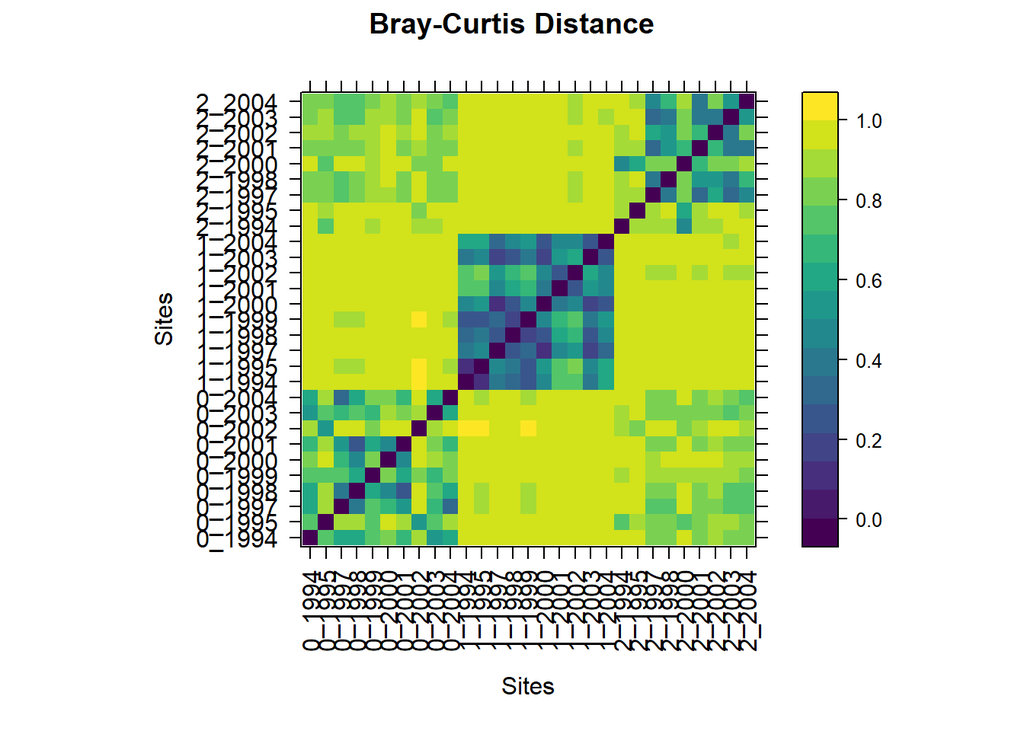

```r
# Load SbS dataset
data = read.csv("./SbS_full.csv", row.names= 1)

# Calculate Bray-Curtis distance
data.db = vegdist(data, method = "bray")

site_labels = rownames(data)

################################################3
# Heatmap of dissimilarities
levelplot(as.matrix(data.db),
  col.regions = viridis,
  aspect="iso",
  xlab = "Sites", ylab = "Sites",
  scales = list(cex=1,
  x=list(labels=site_labels, rot=90),
  y=list(labels=site_labels)),

  main = "Bray-Curtis Distance")
```

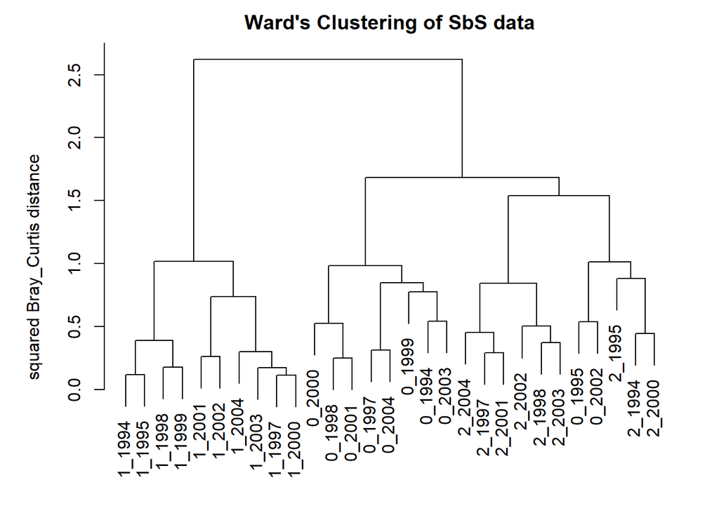

```r
#############################################################3
# Perform cluster analysis
data.ward = hclust(data.db, method = "ward.D2")

# Plot cluster
par(mar=c(1,5,2,2) + 0.1)
plot(data.ward, main = "Ward's Clustering of SbS data",
  ylab = "squared Bray_Curtis distance")
```

```r
######################################################
# PCOA analysis for all sites
data.pcoa = cmdscale(data.db, eig = TRUE, k = 3)
data.pcoa
```

```
## $points
##              [,1]          [,2]         [,3]
## 0_1994 -0.2621034 -0.2699149247  0.074385720
## 0_1995 -0.2359875  0.1595108010  0.344080961
## 0_1997 -0.2932861 -0.3466560108 -0.101197617
## 0_1998 -0.2843073 -0.4276652457 -0.022757800
## 0_1999 -0.2787567 -0.1875842322  0.214850543
## 0_2000 -0.1968760 -0.4002278443  0.074979920
## 0_2001 -0.2911126 -0.4241363107 -0.002957168
## 0_2002 -0.1810289  0.1689894425  0.429592708
## 0_2003 -0.2715348 -0.0947729159  0.083963107
## 0_2004 -0.2536514 -0.3176398880 -0.032678583
## 1_1994  0.4785794 -0.0342757754 -0.006622986
## 1_1995  0.4496789 -0.0833756088 -0.004812516
## 1_1997  0.5275647 -0.0091488844 -0.044266100
## 1_1998  0.5232734 -0.0211786424 -0.016732378
## 1_1999  0.4782747 -0.0766809969 -0.014181681
## 1_2000  0.5258441  0.0031358443 -0.027164795
## 1_2001  0.4180193  0.0467956632 -0.006448752
## 1_2002  0.3339251  0.0615793860 -0.046432316
## 1_2003  0.5299988 -0.0001139364 -0.018876707
## 1_2004  0.4694560  0.0145119790 -0.046857413
## 2_1994 -0.1607187  0.2876104811  0.344095705
## 2_1995 -0.1294679  0.2737598386  0.310008007
## 2_1997 -0.3067167  0.2245664276 -0.351108294
## 2_1998 -0.2760078  0.2372780730 -0.320075152
## 2_2000 -0.2232449  0.3901000122  0.309488417
## 2_2001 -0.3004076  0.2578313078 -0.253731622
## 2_2002 -0.2414980  0.2521335308 -0.248891083
## 2_2003 -0.2830456  0.1993900669 -0.405471601
## 2_2004 -0.2648624  0.1161783626 -0.214180522
##
## $eig
##  [1]  3.500990e+00  1.535678e+00  1.259760e+00  7.007179e-01  5.987093e-01
##  [6]  5.557639e-01  4.598719e-01  4.169859e-01  2.993459e-01  2.604848e-01
## [11]  1.599484e-01  1.426802e-01  1.146544e-01  1.023091e-01  7.670019e-02
## [16]  7.110455e-02  4.697578e-02  4.041310e-02  2.855480e-02  1.651146e-02
## [21]  1.075181e-02  7.489826e-03  4.448349e-03  1.493358e-03  2.436551e-04
## [26]  1.561251e-16 -6.788577e-03 -1.486261e-02 -1.617749e-02
##
## $x
## NULL
##
## $ac
## [1] 0
##
## $GOF
## [1] 0.6025050 0.6046939
```

```r
# Explained variance for first 3 axes
explained_variance = round(sum(data.pcoa$eig[1:3]/sum(data.pcoa$eig)) * 100, 2)
print("Explained variance of the 3 first axes:")
```

```
## [1] "Explained variance of the 3 first axes:"
```

```r
print(explained_variance)
```

```
## [1] 60.69
```

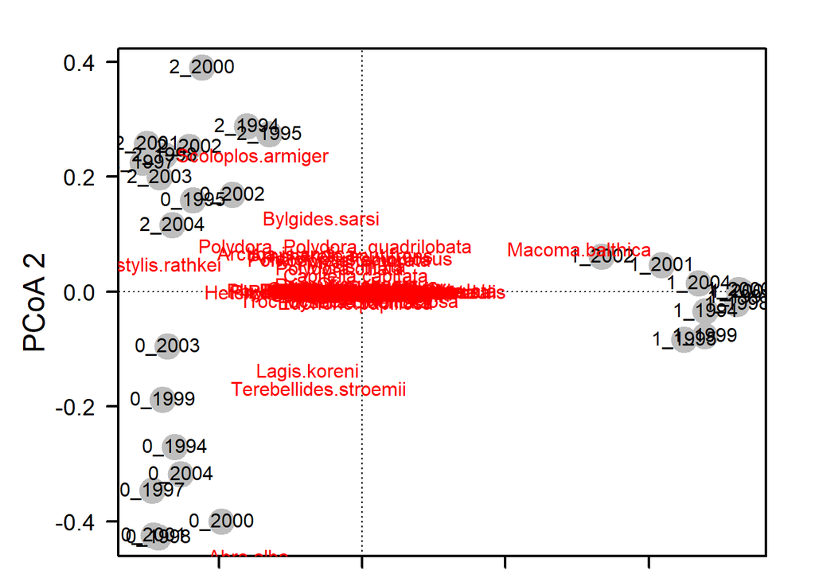

```r
# Define Plot Parameters
par(mar=c(1,5,2,2) + 0.1)

# Initiate Plot
plot(data.pcoa$points[ ,1],
  data.pcoa$points[ ,2],
     xlab = "PCoA 1",
     ylab = "PCoA 2",
     pch = 16, cex = 2,  type = "n", cex.lab = 1.5,
     cex.axis = 0.5, axes = FALSE)

# # Add Axes
axis(side = 1, labels = T, lwd.ticks = 2, cex.axis = 1.2, las = 1)
axis(side = 2, labels = T, lwd.ticks = 2, cex.axis = 1.2, las = 1)
abline(h = 0, v = 0, lty = 3)
box(lwd = 2)

# # Add Points & Labels
points(data.pcoa$points[ ,1],
  data.pcoa$points[ ,2],
  pch = 19, cex = 3, bg = "gray", col = "gray")
text(data.pcoa$points[ ,1], data.pcoa$points[ ,2],
     labels = row.names(data.pcoa$points))

# Add species on top
dataREL <- data
  for(i in 1:nrow(data)){
    dataREL[i, ] = data[i, ] / sum(data[i, ])
    }

# Now, we use this information to calculate and add species scores
data.pcoa <- add.spec.scores(
  data.pcoa,
  dataREL,
  method = "pcoa.scores")

text(
  data.pcoa$cproj[ ,1],
  data.pcoa$cproj[ ,2],
  labels = row.names(data.pcoa$cproj), col = "red",
  cex=1)
```

> *Answer* *Cluster Analysis*

> We see that some sites cluster consistently by location over different years. For example, site 1 contains all the years sampled, this suggests that the zoobenthos community composition is stable over time. Howeverm some other sites (0 and 2) have some temporal shifts. For instance, site 0_1995 and 0_2002 are clustered closer to sites 2_1994 2_1995, 2_2000, suggesting that there might be environmental changes, disturbances, or shifts in the zoobenthos community composition over time.

> *Bray_Curtis Distance Heatmap* We can see shows distinct blocks of similarity between the same site being sampled over years. This was expected. However, we find again that in the early years of site 2 samples (1994,95), site 2 had a zoobenthos biodiversity composition more similar to site 0 of the same year. In conclusion, for sites that show changes over time, we can think that they are locaed in more disturbed areas or are more exposed to environmental changes (pollutionm climate changes, invasive species?)

> *PCOA analysis* Here, we see that the sites 0, 1, 2 parated across the PCoA space, suggesting they have distinct community compositions. Site 1 (e.g., 1_1994, 1_1995, 1_1999, etc.) appears to form a tight cluster, which means that they have a relatively stable species composition over time. Sites 2 and 0(e.g., 2_1994, 2_1995, etc.) are more dispersed across multiple quadrants. This suggests that “these sites” have bigger variation in community composition.

> I think species nearer to the center are more present in most sites. While species far from the origin are more specialized or strongly associated with particular site conditions. There are several patterns : Macoma balthica is strongly associated with site 1. This suggest that this species may adapt well in this site’ specific condition. Scoloplos armiger and Bylgides sarsi are more abundant in these site 2. Abra alba, Lagis koreni, and Terebellides stroemii are characteristic site 0.